# Определение перспективного тарифа для телеком-компании.

В нашем распоряжении данные 500 пользователей компании "Мегалайн": кто они, откуда, каким тарифом пользуются, сколько звонков и сообщений отправил каждый за 2018 г. Для того, чтобы коммерческий департамент скорректировал рекламный бюджет, необхлдимо выяснить, какой тариф приносит больше денег. Нужно сделать предварительный анализ тарифов и поведения клиентов на основе имеющейся небольшой выборки.

```python
import pandas as pd
import matplotlib.pyplot as plt
import numpy as np
import warnings
from scipy import stats as st
warnings.filterwarnings('ignore')
```

## Подготовка данных.

Откроем файлы с данными

```python
data_users = pd.read_csv('users.csv')
data_tariffs = pd.read_csv('tariffs.csv')
data_calls = pd.read_csv('calls.csv')
data_internet = pd.read_csv('internet.csv')
data_messages = pd.read_csv('messages.csv')
```

### Данные о пользователях.

Обратимся к таблице `data_users`

```python
display(data_users.head(10))
data_users.info()
```

|  | user_id | age | churn_date | city | first_name | last_name | reg_date | tariff |
| --- | --- | --- | --- | --- | --- | --- | --- | --- |
| 0 | 1000 | 52 | NaN | Краснодар | Рафаил | Верещагин | 2018-05-25 | ultra |
| 1 | 1001 | 41 | NaN | Москва | Иван | Ежов | 2018-11-01 | smart |
| 2 | 1002 | 59 | NaN | Стерлитамак | Евгений | Абрамович | 2018-06-17 | smart |
| 3 | 1003 | 23 | NaN | Москва | Белла | Белякова | 2018-08-17 | ultra |
| 4 | 1004 | 68 | NaN | Новокузнецк | Татьяна | Авдеенко | 2018-05-14 | ultra |
| 5 | 1005 | 67 | NaN | Набережные Челны | Афанасий | Горлов | 2018-01-25 | smart |
| 6 | 1006 | 21 | NaN | Ульяновск | Леонид | Ермолаев | 2018-02-26 | smart |
| 7 | 1007 | 65 | NaN | Москва | Юна | Березина | 2018-04-19 | smart |
| 8 | 1008 | 63 | NaN | Челябинск | Рустэм | Пономарёв | 2018-12-19 | smart |
| 9 | 1009 | 24 | NaN | Пермь | Василиса | Блинова | 2018-03-22 | smart |

```
<class 'pandas.core.frame.DataFrame'>
RangeIndex: 500 entries, 0 to 499
Data columns (total 8 columns):
 #   Column      Non-Null Count  Dtype
---  ------      --------------  -----
 0   user_id     500 non-null    int64
 1   age         500 non-null    int64
 2   churn_date  38 non-null     object
 3   city        500 non-null    object
 4   first_name  500 non-null    object
 5   last_name   500 non-null    object
 6   reg_date    500 non-null    object
 7   tariff      500 non-null    object
dtypes: int64(2), object(6)
memory usage: 31.4+ KB
```

Таблица с информацией о пользователях содержит 500 строк, в каждой из которых есть данные об имени и фамилии пользователя, городе проживания, дата подключения к тарифу и дате прекращения пользования им, используемый тариф, а также id пользователя. Незаполненные значения есть только в столбце `churn_date`, они говорят о том, что пользователь использовал тариф на момент формирования таблицы.

Как видно данные о датах подключения и отключения тарифа записаны в строковом формате, приведем их к формату datetime Для этого сначала посмотрим в каком виде представлена дата в заполненных значениях столбца `churn_date`

```python
data_users.loc[~data_users['churn_date'].isna()].head()
```

|  | user_id | age | churn_date | city | first_name | last_name | reg_date | tariff |
| --- | --- | --- | --- | --- | --- | --- | --- | --- |
| 19 | 1019 | 63 | 2018-10-05 | Томск | Игнатий | Круглов | 2018-05-16 | ultra |
| 20 | 1020 | 59 | 2018-12-18 | Чита | Тала | Костина | 2018-10-22 | smart |
| 34 | 1034 | 66 | 2018-11-21 | Вологда | Святослав | Бондарев | 2018-08-26 | smart |
| 50 | 1050 | 44 | 2018-10-03 | Тюмень | Рузана | Аничкина | 2018-06-16 | ultra |
| 51 | 1051 | 37 | 2018-10-14 | Москва | Кристина | Сомова | 2018-05-28 | smart |

Представление даты в столбцах `churn_date` и `reg_date` одинаково. приведем их к формату datetime

```python
DATE_FORMAT = '%Y-%m-%d'
data_users['churn_date'] = pd.to_datetime(data_users['churn_date'], format=DATE_FORMAT)
data_users['reg_date'] = pd.to_datetime(data_users['reg_date'], format=DATE_FORMAT)

print(data_users.loc[~data_users['churn_date'].isna(), 'churn_date'].head())
print(data_users['reg_date'].head())
```

```
19   2018-10-05
20   2018-12-18
34   2018-11-21
50   2018-10-03
51   2018-10-14
Name: churn_date, dtype: datetime64[ns]
0   2018-05-25
1   2018-11-01
2   2018-06-17
3   2018-08-17
4   2018-05-14
Name: reg_date, dtype: datetime64[ns]
```

Проверим на наличие скрытых дубликатов в названиях городов.

```python
data_users['city'].sort_values().unique()
```

```
array(['Архангельск', 'Астрахань', 'Балашиха', 'Барнаул', 'Белгород',
       'Брянск', 'Владивосток', 'Владикавказ', 'Владимир', 'Волгоград',
       'Волжский', 'Вологда', 'Воронеж', 'Грозный', 'Екатеринбург',
       'Иваново', 'Ижевск', 'Иркутск', 'Казань', 'Калининград', 'Калуга',
       'Кемерово', 'Киров', 'Кострома', 'Краснодар', 'Красноярск',
       'Курган', 'Курск', 'Липецк', 'Магнитогорск', 'Махачкала', 'Москва',
       'Мурманск', 'Набережные Челны', 'Нижневартовск', 'Нижний Новгород',
       'Нижний Тагил', 'Новокузнецк', 'Новороссийск', 'Новосибирск',
       'Омск', 'Оренбург', 'Орёл', 'Пенза', 'Пермь', 'Петрозаводск',
       'Подольск', 'Ростов-на-Дону', 'Рязань', 'Самара',
       'Санкт-Петербург', 'Саранск', 'Саратов', 'Севастополь', 'Смоленск',
       'Сочи', 'Ставрополь', 'Стерлитамак', 'Сургут', 'Тамбов', 'Тверь',
       'Тольятти', 'Томск', 'Тула', 'Тюмень', 'Улан-Удэ', 'Ульяновск',
       'Уфа', 'Хабаровск', 'Химки', 'Чебоксары', 'Челябинск', 'Череповец',
       'Чита', 'Якутск', 'Ярославль'], dtype=object)
```

Скрытых дубликатов в названиях городов нет.

Проверим на наличие дубликатов

```python
data_users.duplicated().sum()
```

```
0
```

В таблице нет повторяющихся пользователей

Применим метод describe, чтобы посмотреть нет ли аномалий в данных о возрасте.

```python
data_users.describe().T
```

|  | count | mean | std | min | 25% | 50% | 75% | max |
| --- | --- | --- | --- | --- | --- | --- | --- | --- |
| user_id | 500.0 | 1249.500 | 144.481833 | 1000.0 | 1124.75 | 1249.5 | 1374.25 | 1499.0 |
| age | 500.0 | 46.588 | 16.667630 | 18.0 | 32.00 | 46.0 | 62.00 | 75.0 |

Самый младший возраст пользователя в выборке 18 лет, самый старший 75 лет. Аномальных значений нет. Средний возраст - 46,5 лет - практический совпадает с медианным показателем 46 лет.

### Данные о тарифах

Обратимся к таблице с данными о тарифах.

```python
display(data_tariffs)
data_tariffs.info()
```

|  | messages_included | mb_per_month_included | minutes_included | rub_monthly_fee | rub_per_gb | rub_per_message | rub_per_minute | tariff_name |
| --- | --- | --- | --- | --- | --- | --- | --- | --- |
| 0 | 50 | 15360 | 500 | 550 | 200 | 3 | 3 | smart |
| 1 | 1000 | 30720 | 3000 | 1950 | 150 | 1 | 1 | ultra |

```
<class 'pandas.core.frame.DataFrame'>
RangeIndex: 2 entries, 0 to 1
Data columns (total 8 columns):
 #   Column                 Non-Null Count  Dtype
---  ------                 --------------  -----
 0   messages_included      2 non-null      int64
 1   mb_per_month_included  2 non-null      int64
 2   minutes_included       2 non-null      int64
 3   rub_monthly_fee        2 non-null      int64
 4   rub_per_gb             2 non-null      int64
 5   rub_per_message        2 non-null      int64
 6   rub_per_minute         2 non-null      int64
 7   tariff_name            2 non-null      object
dtypes: int64(7), object(1)
memory usage: 256.0+ bytes
```

Таблица содержит информацию о тарифах, импользуемых пользователями - сколько минут, интернета, сообщений входит в тарифный пакет, а также стоимость этих услуг сверх лимита. Все данные, кроме названия тарифа записаны в целочисленном формате. Стоит обратить внимание на то, что информация о количестве интернет-трафика, включенного в тариф записана в мегабайтах, а стоимость трафика сверх пакета указана за гигабайт. Для дальнейших расчетов переведем мегабайты в гигабайты.

```python
data_tariffs['mb_per_month_included'] =  (data_tariffs['mb_per_month_included'] / 1024).astype('int')
data_tariffs.rename(columns={'mb_per_month_included': 'gb_per_month_included', 'tariff_name': 'tariff'}, inplace=True)
data_tariffs
```

|  | messages_included | gb_per_month_included | minutes_included | rub_monthly_fee | rub_per_gb | rub_per_message | rub_per_minute | tariff |
| --- | --- | --- | --- | --- | --- | --- | --- | --- |
| 0 | 50 | 15 | 500 | 550 | 200 | 3 | 3 | smart |
| 1 | 1000 | 30 | 3000 | 1950 | 150 | 1 | 1 | ultra |

### Данные о звонках.

Обратимся к таблице со звонками пользователей.

```python
display(data_calls.head(10))
data_calls.info()
```

|  | id | call_date | duration | user_id |
| --- | --- | --- | --- | --- |
| 0 | 1000_0 | 2018-07-25 | 0.00 | 1000 |
| 1 | 1000_1 | 2018-08-17 | 0.00 | 1000 |
| 2 | 1000_2 | 2018-06-11 | 2.85 | 1000 |
| 3 | 1000_3 | 2018-09-21 | 13.80 | 1000 |
| 4 | 1000_4 | 2018-12-15 | 5.18 | 1000 |
| 5 | 1000_5 | 2018-11-02 | 0.00 | 1000 |
| 6 | 1000_6 | 2018-10-18 | 0.00 | 1000 |
| 7 | 1000_7 | 2018-08-22 | 18.31 | 1000 |
| 8 | 1000_8 | 2018-09-15 | 18.44 | 1000 |
| 9 | 1000_9 | 2018-08-15 | 0.00 | 1000 |

```
<class 'pandas.core.frame.DataFrame'>
RangeIndex: 202607 entries, 0 to 202606
Data columns (total 4 columns):
 #   Column     Non-Null Count   Dtype
---  ------     --------------   -----
 0   id         202607 non-null  object
 1   call_date  202607 non-null  object
 2   duration   202607 non-null  float64
 3   user_id    202607 non-null  int64
dtypes: float64(1), int64(1), object(2)
memory usage: 6.2+ MB
```

Таблица содержит информацию о совершенных пользователями звонках: уникальный номер каждого звонка, уникальный номер пользователя, сделавшего звонок, дата звонка, длительность звонка в минутах. В выведенных на экран первых 10 строках таблицы имеются звонки с нулевой продолжительностью. Это пропущенные звонки, их удалять не нужно.

Как видно дата звонка записана в строковом формате. Преобразуем ее в формат datetime.

```python
data_calls['call_date'] = pd.to_datetime(data_calls['call_date'], format=DATE_FORMAT)
data_calls['call_date'].head()
```

```
0   2018-07-25
1   2018-08-17
2   2018-06-11
3   2018-09-21
4   2018-12-15
Name: call_date, dtype: datetime64[ns]
```

Как известно из вводных данных для анализа, каждый звонок в сети "Мегалайн" округляется отдельно, и даже, если пользователь проговорил всего секунду, засчитывается целая минута. Поэтому округлим время звонков до целых минут в большую сторону и приведем значения в столбце к целочисленному формату.

```python
data_calls['duration'] = data_calls['duration'].apply(np.ceil).astype('int')
data_calls.head()
```

|  | id | call_date | duration | user_id |
| --- | --- | --- | --- | --- |
| 0 | 1000_0 | 2018-07-25 | 0 | 1000 |
| 1 | 1000_1 | 2018-08-17 | 0 | 1000 |
| 2 | 1000_2 | 2018-06-11 | 3 | 1000 |
| 3 | 1000_3 | 2018-09-21 | 14 | 1000 |
| 4 | 1000_4 | 2018-12-15 | 6 | 1000 |

Применим метод describe.

```python
data_calls.describe().T
```

|  | count | mean | std | min | 25% | 50% | 75% | max |
| --- | --- | --- | --- | --- | --- | --- | --- | --- |
| duration | 202607.0 | 7.158198 | 5.959173 | 0.0 | 2.0 | 6.0 | 11.0 | 38.0 |
| user_id | 202607.0 | 1253.940619 | 144.722751 | 1000.0 | 1126.0 | 1260.0 | 1379.0 | 1499.0 |

Максимальная продолжительность звонка 38 минут, средняя 7 минут. Аномальных значений нет. Добавим столбец с месяцем звонков

```python
data_calls['month']= data_calls['call_date'].dt.month
data_calls.head()
```

|  | id | call_date | duration | user_id | month |
| --- | --- | --- | --- | --- | --- |
| 0 | 1000_0 | 2018-07-25 | 0 | 1000 | 7 |
| 1 | 1000_1 | 2018-08-17 | 0 | 1000 | 8 |
| 2 | 1000_2 | 2018-06-11 | 3 | 1000 | 6 |
| 3 | 1000_3 | 2018-09-21 | 14 | 1000 | 9 |
| 4 | 1000_4 | 2018-12-15 | 6 | 1000 | 12 |

### Данные о сообщениях.

Обратимся к таблице с данными о сообщениях, отправленных пользователями в 2018 г.

```python
display(data_messages.head(10))
data_messages.info()
```

|  | id | message_date | user_id |
| --- | --- | --- | --- |
| 0 | 1000_0 | 2018-06-27 | 1000 |
| 1 | 1000_1 | 2018-10-08 | 1000 |
| 2 | 1000_2 | 2018-08-04 | 1000 |
| 3 | 1000_3 | 2018-06-16 | 1000 |
| 4 | 1000_4 | 2018-12-05 | 1000 |
| 5 | 1000_5 | 2018-06-20 | 1000 |
| 6 | 1000_6 | 2018-11-19 | 1000 |
| 7 | 1000_7 | 2018-10-29 | 1000 |
| 8 | 1000_8 | 2018-06-25 | 1000 |
| 9 | 1000_9 | 2018-12-18 | 1000 |

```
<class 'pandas.core.frame.DataFrame'>
RangeIndex: 123036 entries, 0 to 123035
Data columns (total 3 columns):
 #   Column        Non-Null Count   Dtype
---  ------        --------------   -----
 0   id            123036 non-null  object
 1   message_date  123036 non-null  object
 2   user_id       123036 non-null  int64
dtypes: int64(1), object(2)
memory usage: 2.8+ MB
```

Таблица содержит информацию о дате смс-сообщений, отправленных пользователями, а также уникальный номер каждого сообщения и каждого пользователя.

Приведем дату отправки сообщения к формату datetime

```python
data_messages['message_date'] = pd.to_datetime(data_messages['message_date'], format=DATE_FORMAT)
data_messages['message_date'].head()
```

```
0   2018-06-27
1   2018-10-08
2   2018-08-04
3   2018-06-16
4   2018-12-05
Name: message_date, dtype: datetime64[ns]
```

Добавим столбец с месяцем сообщений

```python
data_messages['month']= data_messages['message_date'].dt.month
data_messages.head()
```

|  | id | message_date | user_id | month |
| --- | --- | --- | --- | --- |
| 0 | 1000_0 | 2018-06-27 | 1000 | 6 |
| 1 | 1000_1 | 2018-10-08 | 1000 | 10 |
| 2 | 1000_2 | 2018-08-04 | 1000 | 8 |
| 3 | 1000_3 | 2018-06-16 | 1000 | 6 |
| 4 | 1000_4 | 2018-12-05 | 1000 | 12 |

### Данные об интернет-сессиях

Обратимся к таблице с информацией об интернет-сессиях.

```python
display(data_internet.head(10))
data_internet.info()
```

|  | Unnamed: 0 | id | mb_used | session_date | user_id |
| --- | --- | --- | --- | --- | --- |
| 0 | 0 | 1000_0 | 112.95 | 2018-11-25 | 1000 |
| 1 | 1 | 1000_1 | 1052.81 | 2018-09-07 | 1000 |
| 2 | 2 | 1000_2 | 1197.26 | 2018-06-25 | 1000 |
| 3 | 3 | 1000_3 | 550.27 | 2018-08-22 | 1000 |
| 4 | 4 | 1000_4 | 302.56 | 2018-09-24 | 1000 |
| 5 | 5 | 1000_5 | 399.97 | 2018-10-02 | 1000 |
| 6 | 6 | 1000_6 | 540.08 | 2018-09-07 | 1000 |
| 7 | 7 | 1000_7 | 415.70 | 2018-07-11 | 1000 |
| 8 | 8 | 1000_8 | 505.40 | 2018-10-08 | 1000 |
| 9 | 9 | 1000_9 | 345.54 | 2018-09-03 | 1000 |

```
<class 'pandas.core.frame.DataFrame'>
RangeIndex: 149396 entries, 0 to 149395
Data columns (total 5 columns):
 #   Column        Non-Null Count   Dtype
---  ------        --------------   -----
 0   Unnamed: 0    149396 non-null  int64
 1   id            149396 non-null  object
 2   mb_used       149396 non-null  float64
 3   session_date  149396 non-null  object
 4   user_id       149396 non-null  int64
dtypes: float64(1), int64(2), object(2)
memory usage: 5.7+ MB
```

Таблица содержит данные о дате интернет-сессии, израсходованном трафике в мегабайтах, уникальном номере сессии и пользователя. Кроме того в таблице есть столбец `Unnamed: 0` значения которого дублируют индексы строк, его можно удалить. Также следует привести столбец `session_date` к формату datetime

```python
del data_internet['Unnamed: 0']
data_internet.head()
```

|  | id | mb_used | session_date | user_id |
| --- | --- | --- | --- | --- |
| 0 | 1000_0 | 112.95 | 2018-11-25 | 1000 |
| 1 | 1000_1 | 1052.81 | 2018-09-07 | 1000 |
| 2 | 1000_2 | 1197.26 | 2018-06-25 | 1000 |
| 3 | 1000_3 | 550.27 | 2018-08-22 | 1000 |
| 4 | 1000_4 | 302.56 | 2018-09-24 | 1000 |

```python
data_internet['session_date'] = pd.to_datetime(data_internet['session_date'], format=DATE_FORMAT)
data_internet['session_date'].head()
```

```
0   2018-11-25
1   2018-09-07
2   2018-06-25
3   2018-08-22
4   2018-09-24
Name: session_date, dtype: datetime64[ns]
```

```python
data_internet.describe().T
```

|  | count | mean | std | min | 25% | 50% | 75% | max |
| --- | --- | --- | --- | --- | --- | --- | --- | --- |
| mb_used | 149396.0 | 370.192426 | 278.300951 | 0.0 | 138.1875 | 348.015 | 559.5525 | 1724.83 |
| user_id | 149396.0 | 1252.099842 | 144.050823 | 1000.0 | 1130.0000 | 1251.000 | 1380.0000 | 1499.00 |

Как видно существуют интернет-сессии с нулевым трафиком. Возможно в этих сессиях абонент переключился на другую сеть для подключения к интернету. Максимальное количество потребленного за сессию интернет-трафика 1724,83 мегабайта. Среднее 370,19 мегабайт.

Добавим столбец с месяцем интернет-сессий

```python
data_internet['month']= data_internet['session_date'].dt.month
data_internet.head()
```

|  | id | mb_used | session_date | user_id | month |
| --- | --- | --- | --- | --- | --- |
| 0 | 1000_0 | 112.95 | 2018-11-25 | 1000 | 11 |
| 1 | 1000_1 | 1052.81 | 2018-09-07 | 1000 | 9 |
| 2 | 1000_2 | 1197.26 | 2018-06-25 | 1000 | 6 |
| 3 | 1000_3 | 550.27 | 2018-08-22 | 1000 | 8 |
| 4 | 1000_4 | 302.56 | 2018-09-24 | 1000 | 9 |

### Вывод

Мы изучили все пять предоставленных для анализа таблиц. Преобразовали формат в столбцах, содержащих дату, из строкового в формат datetime. В таблице с данными о тарифах привели информацию об интернет-трафике к одной единице измерения - гигабайтам. Округлили в большую сторону продолжительность звонков в минуту, и преобразовали этот столбец в формат int. Кроме того, удалили из таблицы с интернет-трафиком столбец с артефактами.

В целом данные пригодны для анализа, можем приступать к следующему этапу исследования.

## Подсчет данных для каждого пользователя.

### Группировка данных по пользователям и месяцам.

Сгруппируем таблицу с данными о звонках по пользователям и месяцам

```python
data_calls_gr = data_calls.groupby(['user_id', 'month']).agg({'duration':['sum','count']}).reset_index().droplevel(0, axis=1)
data_calls_gr.columns = ['user_id', 'month','calls_sum', 'calls_count']
data_calls_gr.head()
```

|  | user_id | month | calls_sum | calls_count |
| --- | --- | --- | --- | --- |
| 0 | 1000 | 5 | 159 | 22 |
| 1 | 1000 | 6 | 172 | 43 |
| 2 | 1000 | 7 | 340 | 47 |
| 3 | 1000 | 8 | 408 | 52 |
| 4 | 1000 | 9 | 466 | 58 |

Сгруппируем таблицу с данными о сообщениях по пользователям и месяцам

```python
data_messages_gr = data_messages.groupby(['user_id', 'month']).agg({'id':'count'}).reset_index()
data_messages_gr.columns = ['user_id', 'month','messages_count']
data_messages_gr.head()
```

|  | user_id | month | messages_count |
| --- | --- | --- | --- |
| 0 | 1000 | 5 | 22 |
| 1 | 1000 | 6 | 60 |
| 2 | 1000 | 7 | 75 |
| 3 | 1000 | 8 | 81 |
| 4 | 1000 | 9 | 57 |

Сгруппируем таблицу с данными об интернет сессиях по пользователям и месяцам

```python
data_internet_gr = data_internet.groupby(['user_id', 'month']).agg({'mb_used':'sum'}).reset_index()
data_internet_gr.columns = ['user_id', 'month','mb_used']
data_internet_gr.head()
```

|  | user_id | month | mb_used |
| --- | --- | --- | --- |
| 0 | 1000 | 5 | 2253.49 |
| 1 | 1000 | 6 | 23233.77 |
| 2 | 1000 | 7 | 14003.64 |
| 3 | 1000 | 8 | 14055.93 |
| 4 | 1000 | 9 | 14568.91 |

Переведем интернет-трафик в гигабайты и округлим в большую сторону

```python
data_internet_gr['mb_used'] = (data_internet_gr['mb_used'] / 1024).apply(np.ceil).astype('int')
data_internet_gr.columns = ['user_id', 'month','gb_used']
data_internet_gr.head()
```

|  | user_id | month | gb_used |
| --- | --- | --- | --- |
| 0 | 1000 | 5 | 3 |
| 1 | 1000 | 6 | 23 |
| 2 | 1000 | 7 | 14 |
| 3 | 1000 | 8 | 14 |
| 4 | 1000 | 9 | 15 |

### Объединение таблиц для расчета помесячной выручки с каждого пользователя.

Последовательно объединим сгруппированые таблицы при помощи метода `merge` с параметром `outer` для того, чтобы сохранить все строки.

```python
data = data_calls_gr.merge(data_internet_gr, on = ['user_id', 'month'], how = 'outer')
data.head()
```

|  | user_id | month | calls_sum | calls_count | gb_used |
| --- | --- | --- | --- | --- | --- |
| 0 | 1000 | 5 | 159.0 | 22.0 | 3.0 |
| 1 | 1000 | 6 | 172.0 | 43.0 | 23.0 |
| 2 | 1000 | 7 | 340.0 | 47.0 | 14.0 |
| 3 | 1000 | 8 | 408.0 | 52.0 | 14.0 |
| 4 | 1000 | 9 | 466.0 | 58.0 | 15.0 |

```python
data = data.merge(data_messages_gr, on = ['user_id', 'month'], how = 'outer')
data.head()
```

|  | user_id | month | calls_sum | calls_count | gb_used | messages_count |
| --- | --- | --- | --- | --- | --- | --- |
| 0 | 1000 | 5 | 159.0 | 22.0 | 3.0 | 22.0 |
| 1 | 1000 | 6 | 172.0 | 43.0 | 23.0 | 60.0 |
| 2 | 1000 | 7 | 340.0 | 47.0 | 14.0 | 75.0 |
| 3 | 1000 | 8 | 408.0 | 52.0 | 14.0 | 81.0 |
| 4 | 1000 | 9 | 466.0 | 58.0 | 15.0 | 57.0 |

```python
data = data.merge(data_users, on = ['user_id'], how = 'outer')
data.head()
```

|  | user_id | month | calls_sum | calls_count | gb_used | messages_count | age | churn_date | city | first_name | last_name | reg_date | tariff |
| --- | --- | --- | --- | --- | --- | --- | --- | --- | --- | --- | --- | --- | --- |
| 0 | 1000 | 5.0 | 159.0 | 22.0 | 3.0 | 22.0 | 52 | NaT | Краснодар | Рафаил | Верещагин | 2018-05-25 | ultra |
| 1 | 1000 | 6.0 | 172.0 | 43.0 | 23.0 | 60.0 | 52 | NaT | Краснодар | Рафаил | Верещагин | 2018-05-25 | ultra |
| 2 | 1000 | 7.0 | 340.0 | 47.0 | 14.0 | 75.0 | 52 | NaT | Краснодар | Рафаил | Верещагин | 2018-05-25 | ultra |
| 3 | 1000 | 8.0 | 408.0 | 52.0 | 14.0 | 81.0 | 52 | NaT | Краснодар | Рафаил | Верещагин | 2018-05-25 | ultra |
| 4 | 1000 | 9.0 | 466.0 | 58.0 | 15.0 | 57.0 | 52 | NaT | Краснодар | Рафаил | Верещагин | 2018-05-25 | ultra |

```python
data = data.merge(data_tariffs, on = ['tariff'], how = 'outer')
data.head()
```

|  | user_id | month | calls_sum | calls_count | gb_used | messages_count | age | churn_date | city | first_name | last_name | reg_date | tariff | messages_included | gb_per_month_included | minutes_included | rub_monthly_fee | rub_per_gb | rub_per_message | rub_per_minute |
| --- | --- | --- | --- | --- | --- | --- | --- | --- | --- | --- | --- | --- | --- | --- | --- | --- | --- | --- | --- | --- |
| 0 | 1000 | 5.0 | 159.0 | 22.0 | 3.0 | 22.0 | 52 | NaT | Краснодар | Рафаил | Верещагин | 2018-05-25 | ultra | 1000 | 30 | 3000 | 1950 | 150 | 1 | 1 |
| 1 | 1000 | 6.0 | 172.0 | 43.0 | 23.0 | 60.0 | 52 | NaT | Краснодар | Рафаил | Верещагин | 2018-05-25 | ultra | 1000 | 30 | 3000 | 1950 | 150 | 1 | 1 |
| 2 | 1000 | 7.0 | 340.0 | 47.0 | 14.0 | 75.0 | 52 | NaT | Краснодар | Рафаил | Верещагин | 2018-05-25 | ultra | 1000 | 30 | 3000 | 1950 | 150 | 1 | 1 |
| 3 | 1000 | 8.0 | 408.0 | 52.0 | 14.0 | 81.0 | 52 | NaT | Краснодар | Рафаил | Верещагин | 2018-05-25 | ultra | 1000 | 30 | 3000 | 1950 | 150 | 1 | 1 |
| 4 | 1000 | 9.0 | 466.0 | 58.0 | 15.0 | 57.0 | 52 | NaT | Краснодар | Рафаил | Верещагин | 2018-05-25 | ultra | 1000 | 30 | 3000 | 1950 | 150 | 1 | 1 |

Посмотрим информацию о получившейся таблице

```python
data.info()
```

```
<class 'pandas.core.frame.DataFrame'>
Int64Index: 3216 entries, 0 to 3215
Data columns (total 20 columns):
 #   Column                 Non-Null Count  Dtype
---  ------                 --------------  -----
 0   user_id                3216 non-null   int64
 1   month                  3214 non-null   float64
 2   calls_sum              3174 non-null   float64
 3   calls_count            3174 non-null   float64
 4   gb_used                3203 non-null   float64
 5   messages_count         2717 non-null   float64
 6   age                    3216 non-null   int64
 7   churn_date             189 non-null    datetime64[ns]
 8   city                   3216 non-null   object
 9   first_name             3216 non-null   object
 10  last_name              3216 non-null   object
 11  reg_date               3216 non-null   datetime64[ns]
 12  tariff                 3216 non-null   object
 13  messages_included      3216 non-null   int64
 14  gb_per_month_included  3216 non-null   int32
 15  minutes_included       3216 non-null   int64
 16  rub_monthly_fee        3216 non-null   int64
 17  rub_per_gb             3216 non-null   int64
 18  rub_per_message        3216 non-null   int64
 19  rub_per_minute         3216 non-null   int64
dtypes: datetime64[ns](2), float64(5), int32(1), int64(8), object(4)
memory usage: 515.1+ KB
```

Проверим, на мессте ли все пользователи.

```python
len(data['user_id'].value_counts())
```

```
500
```

Посмотрим на строки с пустыми значениями в месяцах.

```python
data.loc[data['month'].isna()]
```

|  | user_id | month | calls_sum | calls_count | gb_used | messages_count | age | churn_date | city | first_name | last_name | reg_date | tariff | messages_included | gb_per_month_included | minutes_included | rub_monthly_fee | rub_per_gb | rub_per_message | rub_per_minute |
| --- | --- | --- | --- | --- | --- | --- | --- | --- | --- | --- | --- | --- | --- | --- | --- | --- | --- | --- | --- | --- |
| 985 | 1128 | NaN | NaN | NaN | NaN | NaN | 51 | 2018-12-23 | Волжский | Ксения | Агаева | 2018-12-15 | ultra | 1000 | 30 | 3000 | 1950 | 150 | 1 | 1 |
| 3215 | 1371 | NaN | NaN | NaN | NaN | NaN | 50 | 2018-12-30 | Омск | Ириней | Трофимов | 2018-12-25 | smart | 50 | 15 | 500 | 550 | 200 | 3 | 3 |

```python
data.query('user_id == 1128 or user_id == 1371')
```

|  | user_id | month | calls_sum | calls_count | gb_used | messages_count | age | churn_date | city | first_name | last_name | reg_date | tariff | messages_included | gb_per_month_included | minutes_included | rub_monthly_fee | rub_per_gb | rub_per_message | rub_per_minute |
| --- | --- | --- | --- | --- | --- | --- | --- | --- | --- | --- | --- | --- | --- | --- | --- | --- | --- | --- | --- | --- |
| 985 | 1128 | NaN | NaN | NaN | NaN | NaN | 51 | 2018-12-23 | Волжский | Ксения | Агаева | 2018-12-15 | ultra | 1000 | 30 | 3000 | 1950 | 150 | 1 | 1 |
| 3215 | 1371 | NaN | NaN | NaN | NaN | NaN | 50 | 2018-12-30 | Омск | Ириней | Трофимов | 2018-12-25 | smart | 50 | 15 | 500 | 550 | 200 | 3 | 3 |

Это пользователи, которые подключились к тарифам и отказались от них в декабре не воспользовавшись услугами связи. Поскольку у нас нет информации как взымается ежемесячная плата с пользователей. Будем считать, что эти клиенты оплатили полностью тариф за декабрь. Оставим этих пользователей в таблице. Они составляют 0,4% пользователей в выборке.

Месяц заполним как декабрь.

```python
data.loc[data['month'].isna(), 'month'] = 12
data.query('user_id == 1128 or user_id == 1371')
```

|  | user_id | month | calls_sum | calls_count | gb_used | messages_count | age | churn_date | city | first_name | last_name | reg_date | tariff | messages_included | gb_per_month_included | minutes_included | rub_monthly_fee | rub_per_gb | rub_per_message | rub_per_minute |
| --- | --- | --- | --- | --- | --- | --- | --- | --- | --- | --- | --- | --- | --- | --- | --- | --- | --- | --- | --- | --- |
| 985 | 1128 | 12.0 | NaN | NaN | NaN | NaN | 51 | 2018-12-23 | Волжский | Ксения | Агаева | 2018-12-15 | ultra | 1000 | 30 | 3000 | 1950 | 150 | 1 | 1 |
| 3215 | 1371 | 12.0 | NaN | NaN | NaN | NaN | 50 | 2018-12-30 | Омск | Ириней | Трофимов | 2018-12-25 | smart | 50 | 15 | 500 | 550 | 200 | 3 | 3 |

Пропуски в столбцах `calls_sum`, `calls_count`, `gb_used`, `messages_count` означают, что в эти месяцы клиенты не пользовались посчитанными в столбцах услугами. Заменим эти пропуски на 0.

```python
data.loc[data['calls_sum'].isna(), 'calls_sum'] = 0
data.loc[data['calls_count'].isna(), 'calls_count'] = 0
data.loc[data['gb_used'].isna(), 'gb_used'] = 0
data.loc[data['messages_count'].isna(), 'messages_count'] = 0

data.info()
```

```
<class 'pandas.core.frame.DataFrame'>
Int64Index: 3216 entries, 0 to 3215
Data columns (total 20 columns):
 #   Column                 Non-Null Count  Dtype
---  ------                 --------------  -----
 0   user_id                3216 non-null   int64
 1   month                  3216 non-null   float64
 2   calls_sum              3216 non-null   float64
 3   calls_count            3216 non-null   float64
 4   gb_used                3216 non-null   float64
 5   messages_count         3216 non-null   float64
 6   age                    3216 non-null   int64
 7   churn_date             189 non-null    datetime64[ns]
 8   city                   3216 non-null   object
 9   first_name             3216 non-null   object
 10  last_name              3216 non-null   object
 11  reg_date               3216 non-null   datetime64[ns]
 12  tariff                 3216 non-null   object
 13  messages_included      3216 non-null   int64
 14  gb_per_month_included  3216 non-null   int32
 15  minutes_included       3216 non-null   int64
 16  rub_monthly_fee        3216 non-null   int64
 17  rub_per_gb             3216 non-null   int64
 18  rub_per_message        3216 non-null   int64
 19  rub_per_minute         3216 non-null   int64
dtypes: datetime64[ns](2), float64(5), int32(1), int64(8), object(4)
memory usage: 515.1+ KB
```

Пропуски остались только в столбце с датой отключения пользователя от тарифа, эти пропуски соответствуют клиентам, которые на момент формирования выборки еще пользовались указанным тарифом, их заполнять не надо.

Приведем данные к нужным форматам

```python
data['month'] = data['month'].astype('int')
data['calls_sum'] = data['calls_sum'].astype('int')
data['calls_count'] = data['calls_count'].astype('int')
data['gb_used'] = data['gb_used'].astype('int')
data['messages_count'] = data['messages_count'].astype('int')
data.info()
```

```
<class 'pandas.core.frame.DataFrame'>
Int64Index: 3216 entries, 0 to 3215
Data columns (total 20 columns):
 #   Column                 Non-Null Count  Dtype
---  ------                 --------------  -----
 0   user_id                3216 non-null   int64
 1   month                  3216 non-null   int32
 2   calls_sum              3216 non-null   int32
 3   calls_count            3216 non-null   int32
 4   gb_used                3216 non-null   int32
 5   messages_count         3216 non-null   int32
 6   age                    3216 non-null   int64
 7   churn_date             189 non-null    datetime64[ns]
 8   city                   3216 non-null   object
 9   first_name             3216 non-null   object
 10  last_name              3216 non-null   object
 11  reg_date               3216 non-null   datetime64[ns]
 12  tariff                 3216 non-null   object
 13  messages_included      3216 non-null   int64
 14  gb_per_month_included  3216 non-null   int32
 15  minutes_included       3216 non-null   int64
 16  rub_monthly_fee        3216 non-null   int64
 17  rub_per_gb             3216 non-null   int64
 18  rub_per_message        3216 non-null   int64
 19  rub_per_minute         3216 non-null   int64
dtypes: datetime64[ns](2), int32(6), int64(8), object(4)
memory usage: 452.2+ KB
```

### Расчет выручки по пользователям по месяцам.

Посчитаем превышение лимитов по тарифам для пользователей по месяцам, добавим эти данные в таблицу.

```python
data['calls_over'] = data['calls_sum'] - data['minutes_included']
data.loc[data['calls_over'] < 0, 'calls_over'] = 0

data['gb_over'] = data['gb_used'] - data['gb_per_month_included']
data.loc[data['gb_over'] < 0, 'gb_over'] = 0

data['messages_over'] = data['messages_count'] - data['messages_included']
data.loc[data['messages_over'] < 0, 'messages_over'] = 0

data.head()
```

|  | user_id | month | calls_sum | calls_count | gb_used | messages_count | age | churn_date | city | first_name | ... | messages_included | gb_per_month_included | minutes_included | rub_monthly_fee | rub_per_gb | rub_per_message | rub_per_minute | calls_over | gb_over | messages_over |
| --- | --- | --- | --- | --- | --- | --- | --- | --- | --- | --- | --- | --- | --- | --- | --- | --- | --- | --- | --- | --- | --- |
| 0 | 1000 | 5 | 159 | 22 | 3 | 22 | 52 | NaT | Краснодар | Рафаил | ... | 1000 | 30 | 3000 | 1950 | 150 | 1 | 1 | 0 | 0 | 0 |
| 1 | 1000 | 6 | 172 | 43 | 23 | 60 | 52 | NaT | Краснодар | Рафаил | ... | 1000 | 30 | 3000 | 1950 | 150 | 1 | 1 | 0 | 0 | 0 |
| 2 | 1000 | 7 | 340 | 47 | 14 | 75 | 52 | NaT | Краснодар | Рафаил | ... | 1000 | 30 | 3000 | 1950 | 150 | 1 | 1 | 0 | 0 | 0 |
| 3 | 1000 | 8 | 408 | 52 | 14 | 81 | 52 | NaT | Краснодар | Рафаил | ... | 1000 | 30 | 3000 | 1950 | 150 | 1 | 1 | 0 | 0 | 0 |
| 4 | 1000 | 9 | 466 | 58 | 15 | 57 | 52 | NaT | Краснодар | Рафаил | ... | 1000 | 30 | 3000 | 1950 | 150 | 1 | 1 | 0 | 0 | 0 |

5 rows × 23 columns

Посчитаем по-месячно выручку по каждому пользователю в выборке, добавим столбец с выручкой за месяц к таблице.

```python
data['revenue'] =(
data['rub_monthly_fee'] + data['calls_over'] * data['rub_per_minute'] + data['gb_over'] * data['rub_per_gb']
+ data['messages_over'] * data['rub_per_message'] )

data.head()
```

|  | user_id | month | calls_sum | calls_count | gb_used | messages_count | age | churn_date | city | first_name | ... | gb_per_month_included | minutes_included | rub_monthly_fee | rub_per_gb | rub_per_message | rub_per_minute | calls_over | gb_over | messages_over | revenue |
| --- | --- | --- | --- | --- | --- | --- | --- | --- | --- | --- | --- | --- | --- | --- | --- | --- | --- | --- | --- | --- | --- |
| 0 | 1000 | 5 | 159 | 22 | 3 | 22 | 52 | NaT | Краснодар | Рафаил | ... | 30 | 3000 | 1950 | 150 | 1 | 1 | 0 | 0 | 0 | 1950 |
| 1 | 1000 | 6 | 172 | 43 | 23 | 60 | 52 | NaT | Краснодар | Рафаил | ... | 30 | 3000 | 1950 | 150 | 1 | 1 | 0 | 0 | 0 | 1950 |
| 2 | 1000 | 7 | 340 | 47 | 14 | 75 | 52 | NaT | Краснодар | Рафаил | ... | 30 | 3000 | 1950 | 150 | 1 | 1 | 0 | 0 | 0 | 1950 |
| 3 | 1000 | 8 | 408 | 52 | 14 | 81 | 52 | NaT | Краснодар | Рафаил | ... | 30 | 3000 | 1950 | 150 | 1 | 1 | 0 | 0 | 0 | 1950 |
| 4 | 1000 | 9 | 466 | 58 | 15 | 57 | 52 | NaT | Краснодар | Рафаил | ... | 30 | 3000 | 1950 | 150 | 1 | 1 | 0 | 0 | 0 | 1950 |

5 rows × 24 columns

Удалим из таблицы столбцы, которые не нужны для анализа (имя, фамилию клиента, информацию о тарифах, которая есть в таблице с тарифами), а также столбцы с данными о звонках, сообщениях и интернет-трафике сверх-тарифа, которые были добавлены для расчета выручки.

```python
data.info()
```

```
<class 'pandas.core.frame.DataFrame'>
Int64Index: 3216 entries, 0 to 3215
Data columns (total 24 columns):
 #   Column                 Non-Null Count  Dtype
---  ------                 --------------  -----
 0   user_id                3216 non-null   int64
 1   month                  3216 non-null   int32
 2   calls_sum              3216 non-null   int32
 3   calls_count            3216 non-null   int32
 4   gb_used                3216 non-null   int32
 5   messages_count         3216 non-null   int32
 6   age                    3216 non-null   int64
 7   churn_date             189 non-null    datetime64[ns]
 8   city                   3216 non-null   object
 9   first_name             3216 non-null   object
```

[output cut: 16 more lines]

```python
data =(
    data.drop(
        ['first_name',
         'last_name',
         'messages_included',
         'gb_per_month_included',
         'minutes_included',
         'rub_monthly_fee',
         'rub_per_gb',
         'rub_per_message',
         'rub_per_minute',
         'calls_over',
         'gb_over',
         'messages_over'  ],
    axis=1)
)
```

```python
data.info()
data.head()
```

```
<class 'pandas.core.frame.DataFrame'>
Int64Index: 3216 entries, 0 to 3215
Data columns (total 12 columns):
 #   Column          Non-Null Count  Dtype
---  ------          --------------  -----
 0   user_id         3216 non-null   int64
 1   month           3216 non-null   int32
 2   calls_sum       3216 non-null   int32
 3   calls_count     3216 non-null   int32
 4   gb_used         3216 non-null   int32
 5   messages_count  3216 non-null   int32
 6   age             3216 non-null   int64
 7   churn_date      189 non-null    datetime64[ns]
 8   city            3216 non-null   object
 9   reg_date        3216 non-null   datetime64[ns]
 10  tariff          3216 non-null   object
 11  revenue         3216 non-null   int64
dtypes: datetime64[ns](2), int32(5), int64(3), object(2)
memory usage: 263.8+ KB
```

|  | user_id | month | calls_sum | calls_count | gb_used | messages_count | age | churn_date | city | reg_date | tariff | revenue |
| --- | --- | --- | --- | --- | --- | --- | --- | --- | --- | --- | --- | --- |
| 0 | 1000 | 5 | 159 | 22 | 3 | 22 | 52 | NaT | Краснодар | 2018-05-25 | ultra | 1950 |
| 1 | 1000 | 6 | 172 | 43 | 23 | 60 | 52 | NaT | Краснодар | 2018-05-25 | ultra | 1950 |
| 2 | 1000 | 7 | 340 | 47 | 14 | 75 | 52 | NaT | Краснодар | 2018-05-25 | ultra | 1950 |
| 3 | 1000 | 8 | 408 | 52 | 14 | 81 | 52 | NaT | Краснодар | 2018-05-25 | ultra | 1950 |
| 4 | 1000 | 9 | 466 | 58 | 15 | 57 | 52 | NaT | Краснодар | 2018-05-25 | ultra | 1950 |

### Вывод

Для проведения исследования мы сгруппировали данные в таблицах с информацией о звонках, сообщениях и интернет-сессиях по пользователям и месяцам. Посчитали ежемесячный расход минут, гигабайт и сообщений по-месячно для каждого пользователя, согласно условиям в описаниии проекта (а именно: на этапе подготовки данных округлили продолжительность каждого звонка в большую сторону до минуты, а на текущем этапе округлили месячный расход гигабайт по каждому клиенту в большую сторону до гигабайта). Последовательно объеденили сгруппированные таблицы, а также таблицы с данными о пользователях и тарифах в общий датафрейм. В получившейся таблице посчитали помесячно выручку по каждому клиенту, исходя из условий тарифа.

Теперь можно приступать к сравнительному анализу данных.

## Анализ поведения клиентов в зависимости от условий тарифа.

### Общая статистика по тарифам

Посмотрим статистику по клиентам, подключившим тариф "Смарт"

```python
data.loc[data['tariff'] == 'smart'].describe().T
```

|  | count | mean | std | min | 25% | 50% | 75% | max |
| --- | --- | --- | --- | --- | --- | --- | --- | --- |
| user_id | 2230.0 | 1246.562332 | 146.110501 | 1001.0 | 1121.0 | 1240.0 | 1376.0 | 1499.0 |
| month | 2230.0 | 8.348430 | 2.920685 | 1.0 | 6.0 | 9.0 | 11.0 | 12.0 |
| calls_sum | 2230.0 | 417.747534 | 190.476754 | 0.0 | 282.0 | 421.5 | 545.0 | 1435.0 |
| calls_count | 2230.0 | 58.437220 | 25.963572 | 0.0 | 40.0 | 60.0 | 76.0 | 198.0 |
| gb_used | 2230.0 | 16.321525 | 5.756167 | 0.0 | 13.0 | 17.0 | 20.0 | 38.0 |
| messages_count | 2230.0 | 33.369058 | 28.230396 | 0.0 | 10.0 | 28.0 | 51.0 | 143.0 |
| age | 2230.0 | 46.557848 | 16.349865 | 18.0 | 32.0 | 47.0 | 62.0 | 75.0 |
| revenue | 2230.0 | 1289.641704 | 818.370799 | 550.0 | 550.0 | 1021.0 | 1750.0 | 6770.0 |

Посмотрим статистику по клиентам, подключившим тариф "Ультра"

```python
data.loc[data['tariff'] == 'ultra'].describe().T
```

|  | count | mean | std | min | 25% | 50% | 75% | max |
| --- | --- | --- | --- | --- | --- | --- | --- | --- |
| user_id | 986.0 | 1262.957404 | 140.689268 | 1000.0 | 1143.0 | 1277.0 | 1381.00 | 1495.0 |
| month | 986.0 | 8.254564 | 2.872786 | 1.0 | 6.0 | 9.0 | 11.00 | 12.0 |
| calls_sum | 986.0 | 526.089249 | 317.887549 | 0.0 | 282.5 | 518.0 | 751.75 | 1673.0 |
| calls_count | 986.0 | 73.318458 | 43.956739 | 0.0 | 41.0 | 73.5 | 103.75 | 244.0 |
| gb_used | 986.0 | 19.474645 | 9.868057 | 0.0 | 12.0 | 19.0 | 27.00 | 49.0 |
| messages_count | 986.0 | 49.313387 | 47.806040 | 0.0 | 6.0 | 38.0 | 78.75 | 224.0 |
| age | 986.0 | 46.838742 | 17.099807 | 18.0 | 30.0 | 45.0 | 63.00 | 75.0 |
| revenue | 986.0 | 2070.030426 | 376.015578 | 1950.0 | 1950.0 | 1950.0 | 1950.00 | 4800.0 |

### Сравнение количества минут звонков пользователей в месяц по тарифам.

Посчитаем показатели минут звонков в зависимости от тарифа: среднее, дисперсию и стандартное отклонение.

```python
calls_by_tariff = data.groupby('tariff').agg({'calls_sum' : ['median', 'mean', 'var', 'std']}).droplevel(0, axis=1)
calls_by_tariff.columns = ['calls_median', 'calls_mean', 'calls_var', 'calls_std']
calls_by_tariff = calls_by_tariff.merge(data_tariffs[['tariff','minutes_included']], on='tariff').set_index('tariff')

calls_by_tariff['%_mean_inclued'] = round((calls_by_tariff['calls_mean']/calls_by_tariff['minutes_included']*100),2)
calls_by_tariff['%_std_mean'] = round((calls_by_tariff['calls_std']/calls_by_tariff['calls_mean']*100),2)
calls_by_tariff
```

| tariff | calls_median | calls_mean | calls_var | calls_std | minutes_included | %_mean_inclued | %_std_mean |
| --- | --- | --- | --- | --- | --- | --- | --- |
| smart | 421.5 | 417.747534 | 36281.393836 | 190.476754 | 500 | 83.55 | 45.60 |
| ultra | 518.0 | 526.089249 | 101052.493549 | 317.887549 | 3000 | 17.54 | 60.42 |

Если посмотреть на показатели дисперсии и стандартного отклонения, то видно, что разброс количества использованных минут в месяц среди пользователей тарифа "Ультра" на много сильнее (стандартное отклонение больше на 67%), значения в выборке по пользователям тарифа "Смарт" гораздо более однородные. Стандартное отклонение по тарифу "Смарт" составляет 46% от среднего значения, а по тарифу "Ультра"- 60% среднего значения.

Построим гистограммы для показателя израсходованных в месяц минут.

**Распределение потраченных минут звонков в месяц.**

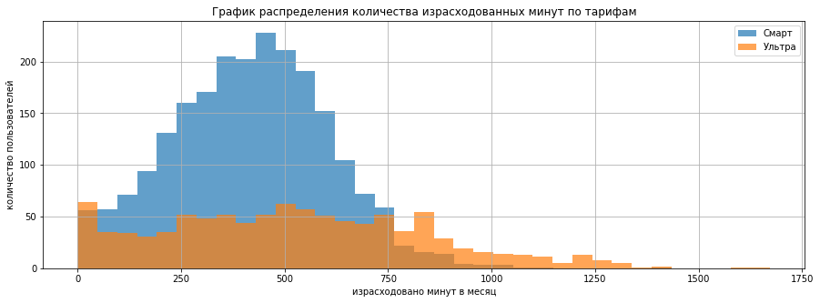

```python
ax = data[data['tariff']== "smart"]['calls_sum'].hist(bins=30, figsize=(15,5), label='Смарт', alpha=0.7)
data[data['tariff']== "ultra"]['calls_sum'].hist(ax=ax, bins=35, figsize=(15,5), label='Ультра', alpha=0.7)
plt.title('График распределения количества израсходованных минут по тарифам')
plt.legend()
plt.ylabel('количество пользователей')
plt.xlabel('израсходовано минут в месяц')
```

**Тариф "Смарт"**

На графике распределения количества минут тарифа "Смарт" мы видим распределение Пуассона (распределение числа событий в единицу времени).Распределение количества израсходованных за месяц минут по пользователям тарифа "Смарт" из-за большого числа событий стремится к нормальному. Оно имеет небольшую скошенность влево (отрицательную), значит значений меньше мелианы в нем больше. Отрицательную скошенность также характерезует и средний показатель 417,74 мин, который меньше медианы (421,5 мин). График, подтверждает, что большинство пользователей не превышают лимит по минутам звонков тарифа.

Также можно сказать, большая часть пользователей тарифа в выборке ежемесячно расходует примерно от 200 до 600 минут на звонки. Пик приходится примерно на 420-450 минут - самыйе часто встречающиеся значения они очень близки к медиане и среднему, что также говорит о нормальности распределения значений в выборке. Имеется небольшое число пользователей (чть больше 50) тратящих в месяц меньше 50 минут на телефонные разговоры.

**Тариф "Ультра"**

Распределение израсходованных минут у пользователей тарифа "Ультра" - это также распределение Пуассона. Но из-за небольшого числа событий (а именно пользователей тарифа "Ультра" в выборке)оно не похоже на нормальное. Имеется несколько пиковых значений. Одно из которых примерно 500-550 минут (что соответствует медианнному значению), а другое 0-50 минут. Пользователей, потративших за месяц меньше 50 минут, даже немного больше, чем 500-550. Возможно, это клиенты, которые большей частью пользуются интернетом, а не звонками, а возможно только подключившиеся клиенты, пользующиеся услугами менее половины месяца.

Гистограмма скошена вправо, значит значений выше медианы в этой группе больше, об этом же говорит и то , что средний показатель выше медианы. Но в, любом случае, пользователей, которые используют хотя бы больше половины тарифного плана по минутам - единицы, они выглядят как отдельные выбивающиеся значения на гистограмме.

### Сравнение количества сообщений в месяц по тарифам.

Посчитаем показатели количества сообщений в зависимости от тарифа: среднее, дисперсию и стандартное отклонение.

```python
messages_by_tariff = data.groupby('tariff').agg({'messages_count' : ['median', 'mean', 'var', 'std']}).droplevel(0, axis=1)
messages_by_tariff.columns = ['messages_median', 'messages_mean', 'messages_var', 'messages_std']
messages_by_tariff = messages_by_tariff.merge(data_tariffs[['tariff','messages_included']], on='tariff').set_index('tariff')

messages_by_tariff['%_mean_inclued'] = round((messages_by_tariff['messages_mean']/messages_by_tariff['messages_included']*100),2)
messages_by_tariff['%_std_mean'] = round((messages_by_tariff['messages_std']/messages_by_tariff['messages_mean']*100),2)
messages_by_tariff
```

| tariff | messages_median | messages_mean | messages_var | messages_std | messages_included | %_mean_inclued | %_std_mean |
| --- | --- | --- | --- | --- | --- | --- | --- |
| smart | 28.0 | 33.369058 | 796.955256 | 28.230396 | 50 | 66.74 | 84.60 |
| ultra | 38.0 | 49.313387 | 2285.417425 | 47.806040 | 1000 | 4.93 | 96.94 |

Пользователи ттарифа "Смарт" из выборки в среднем отправляют 33 сообщения в месяц, что сочтавляет 67% от количества сообщений включенных в тарифный план. Пользователи тарифа "Ультра" из выборки в среднем отправляют 49 сообщений в месяц (на 48% больше пользователей тарифа "Смарт), но это количество составляет всего 4,9% от количества сообщений, включенных в тарифный план "Ультра".

Также из показателей дисперсии и стандартного отклонения видно, что разброс количества отправленных в месяц сообщений относительно среднего у пользователей тарифа "Смарт" несколько меньше, чем у пользователей тарифа "Ультра" ("Смарт"- стандартное отклонение 85% среднего значения, "Ультра"- 97% среднего значения).

Построим гистограммы распределения количества отправленных в месяц сообщений.

**Распределение количества отправленных в месяц сообщений**

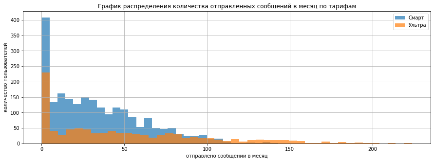

```python
ax = data[data['tariff']== "smart"]['messages_count'].hist(bins=30, figsize=(15,5), label='Смарт', alpha=0.7)
data[data['tariff']== "ultra"]['messages_count'].hist(ax=ax, bins=45, figsize=(15,5), label='Ультра', alpha=0.7)
plt.legend()
plt.title('График распределения количества отправленных сообщений в месяц по тарифам')
plt.ylabel('количество пользователей')
plt.xlabel('отправлено сообщений в месяц')
```

**Тариф "Смарт"**

Здесь распределение Пуассона смещено влево из-за небольшого числа событий (количества отправляемых каждым пользователем выборки сообщений в месяц). Как видно, наиболее часто встречающиеся значения 0-5. Значения, соответствующие среднему и медиане встречаются гораздо реже. Это обусловленно большим разбросом значений в правую сторону (небольшое количество пользователей, отправляющих более 60 сообщений в месяц), они смещают среднее и медиану к большим значениям.

**Тариф "Ультра"**

Здесь также смещенное в лево распределение Пуассона. Количество событий еще меньше, чем в случае с тарифом "Смарт", а разброс значений больше. Самые часто встречающиеся также 0-5 сообщений. Среднее и медиана сильно смещены вправо из-за большого разброса значений (небольшое количество пользователей отправляющих больше 70 сообщений вмесяц). Медиана несколько меньше (38 сообщений), среднее же смещено сильнее (49 сообщений).

### Сравнение интернет-трафика пользователей тарифов "Смарт" и "Ультра"

Посмотрим на среднее, дисперсию и стандартное отклонение количества ежемесячного интернет-трафика по пользователям тарифов из выборки.

```python
gb_by_tariff = data.groupby('tariff').agg({'gb_used' : ['median', 'mean', 'var', 'std']}).droplevel(0, axis=1)
gb_by_tariff.columns = ['gb_used_median', 'gb_used_mean', 'gb_used_var', 'gb_used_std']
gb_by_tariff = gb_by_tariff.merge(data_tariffs[['tariff','gb_per_month_included']], on='tariff').set_index('tariff')

gb_by_tariff['%_mean_inclued'] = round((gb_by_tariff['gb_used_mean']/gb_by_tariff['gb_per_month_included']*100),2)
gb_by_tariff['%_std_mean'] = round((gb_by_tariff['gb_used_std']/gb_by_tariff['gb_used_mean']*100),2)
gb_by_tariff
```

| tariff | gb_used_median | gb_used_mean | gb_used_var | gb_used_std | gb_per_month_included | %_mean_inclued | %_std_mean |
| --- | --- | --- | --- | --- | --- | --- | --- |
| smart | 17.0 | 16.321525 | 33.133453 | 5.756167 | 15 | 108.81 | 35.27 |
| ultra | 19.0 | 19.474645 | 97.378544 | 9.868057 | 30 | 64.92 | 50.67 |

В среднем пользователи тарифа "Смарт" расходуют 16,32 гб интернет-трафика в месяц, что превышает трафик включенный в тариф почти на 9%. Пользователи тарифа "Ультра", включенные в выборку, в среднем расходуют 19,47 гб интернет-трафика, это больше чем у пользователей тарифа "Смарт" всего на 19%. При этом интернет трафик, включеный в тариф "Ультра" выше чем у тарифа "Смарт" в 2 раза. В среднем пользователи тарифа "Ультра" из выборки расходуют лишь 65% интернет-трафика, входящего в тариф.

Глядя на оказатели дисперсии и стандартного отклонения, также, как и в случаях с количеством израсходованных минут звонков и отправленных сообщений, можно сказать, что разброс значений расхода интернет-трафика у тарифа "Ультра" больше, чем у тарифа "Смарт". Стандартное отклонение значений по тарифу "Смарт" составляет 35% от среднего показателя, в тарифе "Ультра" - уже почти 51%.

**Распределение значений использования интернет-трафика в месяц в зависимости от тарифа.**

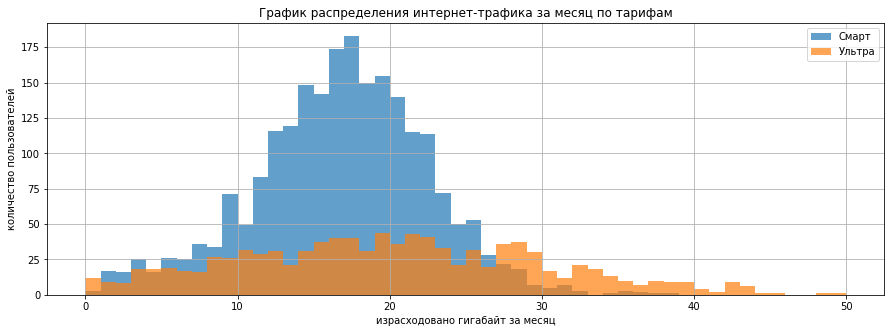

```python
ax = data[data['tariff'] == "smart"]['gb_used'].hist(bins=40, figsize=(15,5), range=(0,40), label='Смарт', alpha=0.7)
data[data['tariff'] == "ultra"]['gb_used'].hist(ax=ax, bins=50, figsize=(15,5), range=(0,50), label='Ультра', alpha=0.7)
plt.legend()
plt.title('График распределения интернет-трафика за месяц по тарифам')
plt.ylabel('количество пользователей')
plt.xlabel('израсходовано гигабайт за месяц')
```

**Тариф "Ультра"**

Полученное распределение Пуассона также стремится к нормальному, хотя имеет множество пиковых значений. Это связано с относительно небольшим количеством пользователей тарифа "Ультра", попавшим в выборку. Здесь наиболее часто встречающийся показатель 19 гб соответствует среднему и медиане. Однако мы видим, что график смещен влево, значит у большего числа пользователей из выборки интернет-трафик меньше медианы. Средний показатель же немного выше медианы, это обусловлено небольшим количеством пользователей с высоким интернет-трафиком (более 35 гб).

### Вывод

Сравнив средние показатели минут звонков, количества сообщений и интернт-трафика, потраченных пользователями за месяц мы увидели:

- Пользователи тарифа "Смарт" расходуют в среднем 84% минут звонков, включенных в тариф и 67% сообщений. Интернат-трафика в среднем расходуется больше чем включено в тариф на 9%. Средняя выручка с пользователя в месяц выше базовой платы за тариф на 134%. Большая часть пользователей в выборке оплачивает дополнительные услуги сверх тарифа.
- Пользователи тарифа "Ультра" в среднем расходуют всего 18% минут звонков и 5% сообщений включенных в тариф. Интернт-трафика в среднем используется 65% от включенного в тариф. Средняя выручка с пользователя в месяц 2070 руб. - выше базовой платы за тариф на 6%. Основная часть пользователей тарифа "Ультра" включенных в выборку не пользуется дополнительными услугами сверх включенных в тариф.
- По показателям дисперсии и стандартного отклонения можно сказать, что разброс данных по количеству минут, сообщений и интернет-трафика у пользователей тарифа "Ультра" больше чем у пользователей тарифа "Смарт". Это видно и на гистограммах распределений по тарифам. Гистограммы построенные на основе данных по тарифу "Смарт" больше стремятся к нормальному распределению и содержат меньше выбивающихся значений и аномальных пиковых значений.

## Проверка гипотез о средней выручке по тарифам.

### Сравнение показателей выручки по тарифам.

Посмотрим на показатели выручки по тарифам.

```python
revenue_by_tariff = data.groupby('tariff').agg({'revenue' : ['median', 'mean', 'var', 'std']}).droplevel(0, axis=1)
revenue_by_tariff.columns = ['revenue_median', 'revenue_mean', 'revenue_var', 'revenue_std']
revenue_by_tariff = revenue_by_tariff.merge(data_tariffs[['tariff','rub_monthly_fee']], on='tariff').set_index('tariff')

revenue_by_tariff['%_mean_monthly_fee'] = round((revenue_by_tariff['revenue_mean']/revenue_by_tariff['rub_monthly_fee']*100),2)
revenue_by_tariff['%_std_mean'] = round((revenue_by_tariff['revenue_std']/revenue_by_tariff['revenue_mean']*100),2)
revenue_by_tariff
```

| tariff | revenue_median | revenue_mean | revenue_var | revenue_std | rub_monthly_fee | %_mean_monthly_fee | %_std_mean |
| --- | --- | --- | --- | --- | --- | --- | --- |
| smart | 1021.0 | 1289.641704 | 669730.763895 | 818.370799 | 550 | 234.48 | 63.46 |
| ultra | 1950.0 | 2070.030426 | 141387.714809 | 376.015578 | 1950 | 106.16 | 18.16 |

Средняя выручка пользователей тарифа "Смарт", как мы уже отмечали 1289,64р., "Ультра" - 2070р. В отличие от показателей минут, сообщений и интернет-трафика, дисперсия и стандартное отклонение у выручки пользователей "Ультра" гораздо меньше, чем у пользователей "Смарт". Разброс показателей выручки у пользователей тарифа "Смарт" больше, они в основной своей части оплачивают услуги связи сверх тарифа. Пользователи тарифа ультра в большинстве оплачивают только ежемесячный тариф. Средняя выручка пользователей тарифа "Ультра" из выборки выше выручки пользователей тарифа "Смарт" на 60%.

**Распределение выручки по пользователям в зависимости от тарифа.**

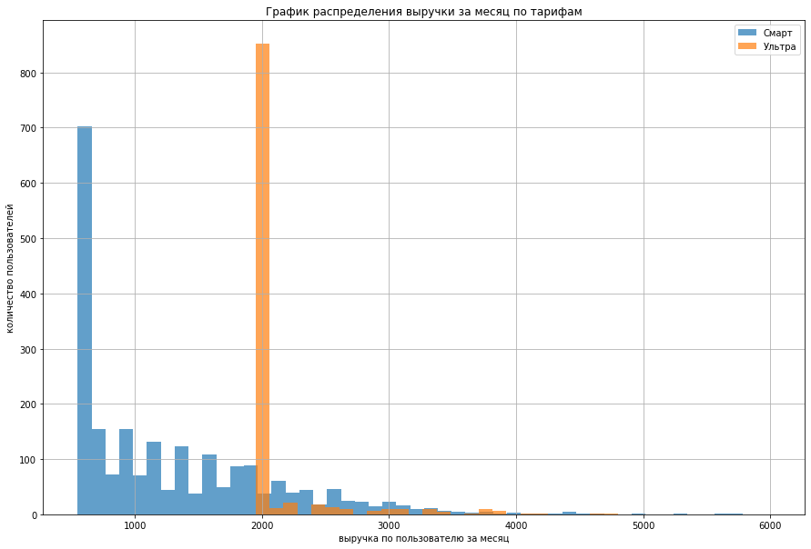

```python
ax = data[data['tariff'] == "smart"]['revenue'].hist(bins=50, figsize=(15,10), range=(550,6000), label='Смарт', alpha=0.7)
data[data['tariff'] == "ultra"]['revenue'].hist(ax=ax, bins=26, figsize=(15,10), range=(1950,4800), label='Ультра', alpha=0.7)
plt.legend()
plt.title('График распределения выручки за месяц по тарифам')
plt.ylabel('количество пользователей')
plt.xlabel('выручка по пользователю за месяц')
```

На графике распределения также видно, что разброс значений выручки пользователей тарифа "Смарт" гораздо больше, чем у пользователей "Ультра". Пользователи тарифа "Ультра" в подавляющем большинстве оплачивают только базовый тариф. Значений выше крайне мало. Среди клиентов подключивших тариф "Смарт" самое пиковое значение также на сумме равной базовому тарифу. Но, в отличии от "Ультра", достаточно много значений выручки, превышающей базовый тариф. График имеет длинный хвост вправо.

### Проверка гипотезы о том, что средняя выручка пользователей тарифов "Ультра" и "Смарт" различается.

По данным выборки средняя выручка полльзователей тарифа "Ультра" выше выручки пользователей тарифа "Смарт" на 60%. Проверим гипотезу о том, что эти средние показатели различны статистическим методом.

Для проверки гипотезы примем за нулевую гипотезу предположение, что средняя выручка пользователей тарифов "Ультра" и "Смарт" равны. Проверка гипотез о равенстве средних двух генеральных совокупностей осуществляется с помощью метода `scipy.stats.ttest_ind`. Альтернативной гипотезой будет предположение о том, что средние выручки пользователей тарифов "Ультра" и "Смарт" различаются.

```python
alpha=0.05

results = st.ttest_ind(data.loc[data['tariff'] == 'smart', 'revenue'], data.loc[data['tariff'] == 'ultra', 'revenue'])
print('p-значение:', results.pvalue)
if results.pvalue < alpha:
    print('Отвергаем нулевую гипотезу')
else:
    print('Не получилось отвергнуть нулевую гипотезу')
```

```
p-значение: 8.081909555489933e-161
Отвергаем нулевую гипотезу
```

Вероятность того, что средняя выручка пользователей по тарифам равна меньше статистически значимой, значит у нас есть основания отвергнуть нулевую гипотезу и не отвергать альтернативную гипотезу о том,что средние выручки по тарифам различаются. Данные из выборки соответствуют этой гипотезе.

### Проверка гипотезы, о том, что средняя выручка пользователей из Москвы отличается от выручки пользователей из других регионов.

Посмотрим на показатели выручки по пользователям из Москвы и по пользователям из других городов.

```python
revenue_moscow = data.query('city == "Москва"').agg({'revenue' : ['median', 'mean', 'var', 'std']}).T
revenue_others = data.query('city != "Москва"').agg({'revenue' : ['median', 'mean', 'var', 'std']}).T

print('Статистика выручки по пользователям из Москвы')
display(revenue_moscow)
print('Статистика выручки по пользователям из других регионов')
display(revenue_others)
```

```
Статистика выручки по пользователям из Москвы
```

|  | median | mean | var | std |
| --- | --- | --- | --- | --- |
| revenue | 1750.0 | 1546.713584 | 565636.467012 | 752.088071 |

```
Статистика выручки по пользователям из других регионов
```

|  | median | mean | var | std |
| --- | --- | --- | --- | --- |
| revenue | 1583.0 | 1524.725144 | 654069.574963 | 808.74568 |

Как видно средняя выручка по пользователям из Москвы выше средней выручки пользователей из других регионов в выборке всего на 1%. Проверим гипотезу о том, что эти показатели отличаются статистическим методом. Используем метод проверки гипотез о равенстве средних двух генеральных совокупностей `scipy.stats.ttest_ind`. За нулевую гипотезу примем гипотезу о равенстве средней выручки пользователей из Москвы и пользователей из других регионов. Соответственно альтернативной гипотезой будет предположение о том, что эти выручки различаются.

```python
results = st.ttest_ind(data.loc[data['city'] == 'Москва', 'revenue'], data.loc[data['tariff'] != 'Москва', 'revenue'])
print('p-значение:', results.pvalue)
if results.pvalue < alpha:
    print('Отвергаем нулевую гипотезу')
else:
    print('Не получилось отвергнуть нулевую гипотезу')
```

```
p-значение: 0.6099466486132994
Не получилось отвергнуть нулевую гипотезу
```

### Вывод

Если сравнивать средние значения из имеющейся выборки, то можно увидеть, что средняя выручка пользователей тарифа "Ультра" выше, чему у пользователей тарифа "Смарт" на 60%. При сравнении средней выручки пользователей из Москвы с выручкой пользователей из других регионов в выборке явных различий не выявлено. Средняя выручка клиентов из Москвы выше всего на 1%.

Проверка этих гипотез статистическими методами показала:

## Общее сравнение средних показателей по тарифам.

Чтобы понять, какой тариф более выгоден для компании, сравним средние показатели двух тарифов.

```python
mean_by_tariff = pd.DataFrame(revenue_by_tariff, columns=['revenue_mean'])
mean_by_tariff = mean_by_tariff.merge(calls_by_tariff['calls_mean'], on='tariff')
mean_by_tariff = mean_by_tariff.merge(messages_by_tariff['messages_mean'], on='tariff')
mean_by_tariff = mean_by_tariff.merge(gb_by_tariff['gb_used_mean'], on='tariff')
mean_by_tariff = mean_by_tariff.T
mean_by_tariff['%_smart_ultra'] = round((mean_by_tariff['ultra']/mean_by_tariff['smart']*100-100),2)
mean_by_tariff
```

| tariff | smart | ultra | %_smart_ultra |
| --- | --- | --- | --- |
| revenue_mean | 1289.641704 | 2070.030426 | 60.51 |
| calls_mean | 417.747534 | 526.089249 | 25.93 |
| messages_mean | 33.369058 | 49.313387 | 47.78 |
| gb_used_mean | 16.321525 | 19.474645 | 19.32 |

При сравнении средних показателей получается, что средняя выручка по тарифу ультра выше на 60%, в то время как среднее количество минут звонков выше всего на 25%, интернет-трафика на 19%, самая большая разница в процентах у смс сообщений, но это из-за их небольшого в среднем их количества у пользователей обоих тарифов (пользователи тарифа "Ультра" расходуют всего 5% пакета сообщений, включенных в тариф).

Для наглядности посчитаем и выведем на экран данные о том, какое количество услуг предоставляет компания за 1 рубль пользователям каждого тарифа согласно его условиям, а какое фактически, исходя из средних данных выборки по пользователям.

```python
servic_for_rub = pd.DataFrame(data=[['minutes_for_1rub', round((500/550),3), round((3000/1950),3), round((418/1290),3), round((526/2070),3)],
                                  ['messages_for_1rub', round((50/550),3), round((1000/1950),3), round((33/1290),3), round((49/2070),3)],
                                  ['gb_for_1rub', round((15/550),3), round((30/1950),3),round((16/1290),3),round((19/2070),3)]
                                   ],
                           columns = ['service',
                                      'smart', 'ultra', 'smart_mean', 'ultra_mean']).set_index('service')
servic_for_rub['%_ul_sm'] = round((servic_for_rub['ultra'] / servic_for_rub['smart'] *100-100), 2)
servic_for_rub['%_ul_sm_mean'] = round((servic_for_rub['ultra_mean'] / servic_for_rub['smart_mean'] *100-100), 2)
servic_for_rub
```

| service | smart | ultra | smart_mean | ultra_mean | %_ul_sm | %_ul_sm_mean |
| --- | --- | --- | --- | --- | --- | --- |
| minutes_for_1rub | 0.909 | 1.538 | 0.324 | 0.254 | 69.20 | -21.60 |
| messages_for_1rub | 0.091 | 0.513 | 0.026 | 0.024 | 463.74 | -7.69 |
| gb_for_1rub | 0.027 | 0.015 | 0.012 | 0.009 | -44.44 | -25.00 |

По условиям тарифа самое большое количество услуг за 1 потраченный рубль получают пользователи тарифа "Ультра" (за исключением интернета, получается, что у тарифа "Смарт" интернет-трафик дешевле), но, поскольку большинство пользователей тарифа "Ультра" в выборке не полностью используют включенный в тариф пакет услуг, за каждый потраченный рубль они получают меньше услуг: минут звонков на 21,6 %, сообщений на 7,69% и интернета на 25%.

## Общий вывод

В ходе исследования на основе выборки из 500 клиентов компании "Мегалайн" нам нужно было выяснить какой из предлагаемых компанией тарифов приносит больше денег, чтобы скорректировать рекламный бюджет.

Проанализировав поведение клиентов из выборки в зависимости от тарифа мы выявили следующие характерные особенности:

- Пользователи тарифа "Смарт" в среднем используют большую часть услуг включенных в тариф (84% минут звонков, 67% сообщений), интернет-трафика в среднем расходуется больше, чем включено в пакет на 9%. Пользователи тарифа "Смарт" более склонны к использованию дополнительных услуг, не включенных в тариф. Их среднемесячная выручка в выборке выше базовой платы за тариф на 134%.
- Пользователи тарифа "Ультра" практически не пользуются дополнительными услугами не включенными в пакет. Также основная часть пользователей тарифа не расходует полностью пакет услуг включенных в тариф. В среднем расходуется 18% минут звонков, 5% сообщений и 65% интернета. Среднемесячная выручка пользователей тарифа "Ультра" из выборке превышает базовоу плату за тариф всего на 6%.

При этом, сравнивая среднюю выручку пользователей из выборки, мы видим, что средняя выручка по тарифу "Ультра" на 60% выше средней выручки по тарифу "Смарт". Сравнивая фактические средние объемы потребленных клиентами из выборки услуг в зависимости от тарифа видно, что в среднем пользователи тарифа "Ультра" за каждый потраченный рубль получают меньший объем услуг, чем пользователи тарифа "Смарт" (интернета на 25%, минут звонков на 21,6%, сообщений на 7,69%).

Основываясь на полученных данных, можно сделать вывод, что не смотря на то что пользователи тарифа "Смарт" оплачивают больше дополнительных услуг, компании "Мегалайн" приносит больше денег один средний пользователь тарифа "Ультра", чем один средний пользователь тарифа "Смарт". Также нами было проверено статистическими методами две гипотезы.